# Handwritten Digits Classification with KNN/NN/CNN

# 4. Random Classifier

First of all, we want to know if we are purely guessing randomly, what will the accuracy be. By common sense, we are guessing from 10 digits randomly when only 1 digit is the correct answer. We expect the accuracy to be around 10%

```python
# a sample classifier
# given an input it outputs a random class
class RandomClassifier():
    def __init__(self, classes=10):
        self.classes=classes
    def __call__(self, x):
        return np.random.randint(self.classes, size=x.shape[0])

#implement the randomClassifier
randomClassifier = RandomClassifier()
```

Now let's see the confusion matrix of our random classifier.

```
50it [00:00, 3342.13it/s]
```

```
Random classifier accuracy: 10.02%
```

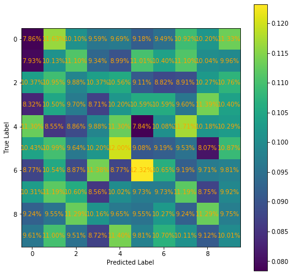

```python
M, accuracy = Confusion(testData, testLabels, randomClassifier)
print('Random classifier accuracy: {:.2%} \n'.format(accuracy))
VisualizeConfusion(M)
```

# 5. K-Nearest Neighbors (KNN)

> In k-NN classification, the output is a class membership. An object is classified by a plurality vote of its neighbors, with the object being assigned to the class most common among its k nearest neighbors (k is a positive integer, typically small). If k = 1, then the object is simply assigned to the class of that single nearest neighbor. [(Wiki)](https://en.wikipedia.org/wiki/K-nearest_neighbors_algorithm)

Here we implement a simple knn classifier using sklearn's KNeighborsClassifier. The distance metric is Euclidean in pixel space, and k, the number of neighbors involved in voting, is set to be 3.

```python
from sklearn.neighbors import KNeighborsClassifier
from sklearn.metrics import plot_confusion_matrix
import numpy as np
import matplotlib.pyplot as plt
class KNNClassifier():
    def __init__(self, k=3):
        # k is the number of neighbors involved in voting
        self.classifier = KNeighborsClassifier(n_neighbors=k)

    def train(self, trainData, trainLabels):
        n,H,W = trainData.shape
        tD=np.reshape(trainData,(n,H*W))
        self.classifier.fit(tD,trainLabels)

    def __call__(self, x):
        # this method should take a batch of images
        # and return a batch of predictions
        n,H,W = x.shape
        tD=np.reshape(x,(n,H*W))
        return self.classifier.predict(tD)
```

```
50it [00:36,  1.38it/s]
```

```
Random classifier accuracy: 97.04%
```

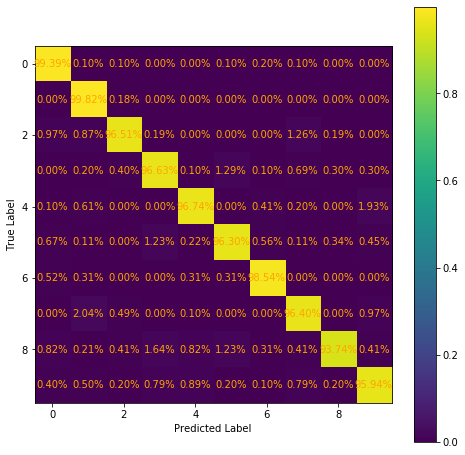

```python
# test your classifier trained with all the training examples
knnClassifier = KNNClassifier()
knnClassifier.train(trainData[:-1], trainLabels[:-1])
# display confusion matrix and testing accuracy for your KNN classifier trained with all the training examples
M, accuracy = Confusion(testData, testLabels, knnClassifier)
print('Random classifier accuracy: {:.2%} \n'.format(accuracy))
VisualizeConfusion(M)
```

# 6. Neural Nets

We will be using PyTorch and it's `nn` module to set a framework for our neural network.

> The nn package defines a set of Modules, which are roughly equivalent to neural network layers. A Module receives input Tensors and computes output Tensors, but may also hold internal state such as Tensors containing learnable parameters.[(PyTorch)](https://pytorch.org/tutorials/beginner/pytorch_with_examples.html)

## 6.1 Helper functions

We defined class `PTClassifier` as our custom classifier container class. The train function for PTClassifier will be used with different networks later on in this project.

```python
# base class for PyTorch networks. The full training loop includes
# (__init__), (train) and prediction(__call__)
from __future__ import print_function
import torch
import torch.nn as nn
from torch.nn.parameter import Parameter
import torch.nn.functional as F
import torch.nn.init
import torch.optim as optim
from torch.autograd import Variable
from tqdm import tqdm
from scipy.stats import truncnorm

class PTClassifier():
    def __init__(self, net):
        self.net = net()

    def train(self, trainData, trainLabels, testData, testLabels, epochs=1, batchsize=50):
        criterion = nn.CrossEntropyLoss() #loss function
        learning_rate=3e-4
        optimizer = optim.Adam(self.net.parameters(),lr=learning_rate) #Optimizer keep and update weights/bias

        for epoch in range(epochs):

            #train models in 50 batches
            for i, (data,label) in enumerate(DataBatch(trainData, trainLabels, batchsize, shuffle=True)):
                inputs = Variable(torch.FloatTensor(data))
                targets = Variable(torch.LongTensor(label))

                # Train the model using the optimizer and the batch data
                optimizer.zero_grad()   # zero the gradient buffers
                output = self.net(inputs)    #get output
                loss = criterion(output, targets) #calculate loss gradient w.r.t output
                loss.backward()    #back propogate to get loss gradient w.r.t input
                optimizer.step()     #update weights and bias

            print ('Epoch:{:d} Accuracy: {:.2%}'.format(epoch+1, test(testData, testLabels, self)))

    #predict(x)
    def __call__(self, x):
        inputs = Variable(torch.FloatTensor(x))
        prediction = self.net(inputs)
        return np.argmax(prediction.data.cpu().numpy(), 1)

    def get_first_layer_weights(self):
        return self.net.weight1.data.cpu().numpy()

# helper function to get weight variable
def weight_variable(shape):
    initial = torch.Tensor(truncnorm.rvs(-1/0.01, 1/0.01, scale=0.01, size=shape))
    return Parameter(initial, requires_grad=True)

# helper function to get bias variable
def bias_variable(shape):
    initial = torch.Tensor(np.ones(shape)*0.1)
    return Parameter(initial, requires_grad=True)
```

## 6.2 Single Layer Perceptron

We implemented single layer perceptron and test its performance

```python
# Define Single Layer Perceptron network
class SLP(nn.Module):
    def __init__(self, in_features=28*28, classes=10):
        super(SLP, self).__init__()
        # model variables
        self.weight1 = weight_variable((classes, in_features))
        self.bias1 = bias_variable((classes))

    def forward(self, x):
        # linear operation
        y_pred = torch.addmm(self.bias1, x.view(list(x.size())[0], -1), self.weight1.t())
        return y_pred
```

```python
# test the example linear classifier (note you should get around 92% accuracy
# for 10 epochs and batchsize 50)
trainData=np.array(list(read('training','images')))    #read data
trainData=np.float32(np.expand_dims(trainData,-1))/255    #expand into (60000,28,28,1)
trainData=trainData.transpose((0,3,1,2))    #(60000,1,28,28)
trainLabels=np.int32(np.array(list(read('training','labels'))))

testData=np.array(list(read('testing','images')))
testData=np.float32(np.expand_dims(testData,-1))/255
testData=testData.transpose((0,3,1,2))
testLabels=np.int32(np.array(list(read('testing','labels'))))
```

```
Epoch:1 Accuracy: 89.07%
Epoch:2 Accuracy: 90.79%
Epoch:3 Accuracy: 91.40%
Epoch:4 Accuracy: 91.73%
Epoch:5 Accuracy: 91.80%
Epoch:6 Accuracy: 92.12%
Epoch:7 Accuracy: 92.14%
Epoch:8 Accuracy: 92.28%
Epoch:9 Accuracy: 92.31%
```

```
50it [00:00, 1432.32it/s]
```

```
Epoch:10 Accuracy: 92.41%
Linear classifier accuracy: 92.41%
```

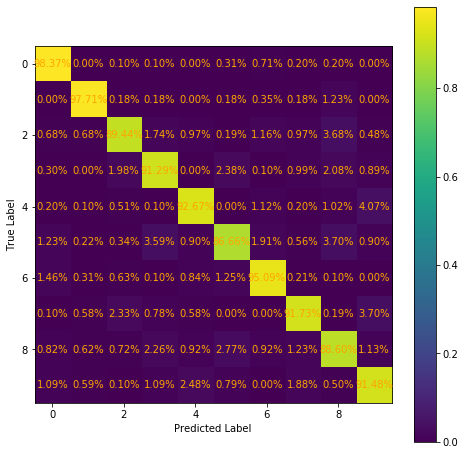

```python
linearClassifier = PTClassifier(SLP)
linearClassifier.train(trainData, trainLabels, testData, testLabels, epochs=10)

M,accuracy= Confusion(testData, testLabels, linearClassifier)
print ('Linear classifier accuracy: {:.2%}'.format(accuracy))
VisualizeConfusion(M)
```

### Filter weights

Now let's look at the filter weights corresponding to each output class as images.

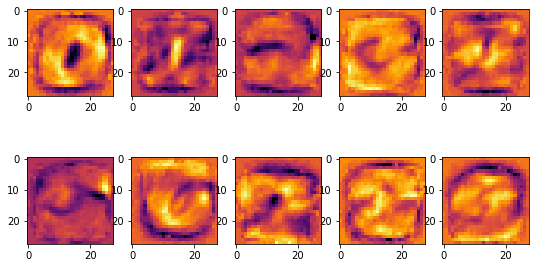

```python
weights=linearClassifier.get_first_layer_weights()

fig, ax = plt.subplots(nrows=2, ncols=5)
fig.set_size_inches(9, 5)
plt.set_cmap('inferno')
i = 0
for row in ax:
    for col in row:
        m=weights[i]
        wgt = (m-m.min()) /(m.max()-m.min())   #normalized to (0,1)
        col.imshow(wgt.reshape((28,28)))
        i += 1
```

### Comment

Here's the numbers that the filter weights of each digit class looks like  
0) 0  
1) combination of 2 and 7  
2) 2  
3) 3  
4) combination of 4 and 9  
5) 5  
6) 6  
7) combination of 7 and 2  
8) combinations of 8 and 3  
9) combination of 9 and 2